# Economic and health consequences of severe weather events

## Synopsis

A short analysis of severe weather events occured in the US from 1950 to 2011 was carried out using the U.S. National Oceanic and Atmospheric Administration’s (NOAA) storm database. Ten most harmful events with respect to population health along with events causing the greatest economic consequences were determined. Health damage was assessed using number of fatalities and injures caused by various events. Tornadoes were identified as most harmful weather conditions causing more then 5500 fatalities followed by excessive heat and floods. Economic consequences were divided into crop damage and property damage. Floods, typhoons and tornadoes, being the most destructive events, caused the most property damage while droughts, floods, hails and ice storms account for the largest part of crop damage.

## Data Processing

```r
# Loading packages
library(dplyr, warn.conflicts = FALSE)
library(tidyr)
library(ggplot2)

# Downloading the dataset and reading in the data
url = "https://d396qusza40orc.cloudfront.net/repdata%2Fdata%2FStormData.csv.bz2"
if (!file.exists("storm_data.csv")) {
    download.file(url, destfile = "storm_data.csv")
}
sdata <- read.csv("storm_data.csv") %>%
    as_tibble()
```

Let’s explore variable names and extract the variables relevant to our analysis:

```r
names(sdata)
```

```
 [1] "STATE__"    "BGN_DATE"   "BGN_TIME"   "TIME_ZONE"  "COUNTY"
 [6] "COUNTYNAME" "STATE"      "EVTYPE"     "BGN_RANGE"  "BGN_AZI"
[11] "BGN_LOCATI" "END_DATE"   "END_TIME"   "COUNTY_END" "COUNTYENDN"
[16] "END_RANGE"  "END_AZI"    "END_LOCATI" "LENGTH"     "WIDTH"
[21] "F"          "MAG"        "FATALITIES" "INJURIES"   "PROPDMG"
[26] "PROPDMGEXP" "CROPDMG"    "CROPDMGEXP" "WFO"        "STATEOFFIC"
[31] "ZONENAMES"  "LATITUDE"   "LONGITUDE"  "LATITUDE_E" "LONGITUDE_"
[36] "REMARKS"    "REFNUM"
```

As can be seen, economic consequences can be estimated using `PROPDMG` and `CROPDMG` variables along with the corresponding `*EXP` variables. Population health can be expressed with number of fatalities and injuries caused by different events (`FATALITIES` and `INJURIES` variables).

```r
sdata <- select(sdata, EVTYPE, FATALITIES, INJURIES, CROPDMG, CROPDMGEXP, PROPDMG, PROPDMGEXP)
summary(sdata)
```

```
               EVTYPE         FATALITIES          INJURIES
 HAIL             :288661   Min.   :  0.0000   Min.   :   0.0000
 TSTM WIND        :219940   1st Qu.:  0.0000   1st Qu.:   0.0000
 THUNDERSTORM WIND: 82563   Median :  0.0000   Median :   0.0000
 TORNADO          : 60652   Mean   :  0.0168   Mean   :   0.1557
 FLASH FLOOD      : 54277   3rd Qu.:  0.0000   3rd Qu.:   0.0000
 FLOOD            : 25326   Max.   :583.0000   Max.   :1700.0000
 (Other)          :170878
    CROPDMG          CROPDMGEXP        PROPDMG          PROPDMGEXP
 Min.   :  0.000          :618413   Min.   :   0.00          :465934
 1st Qu.:  0.000   K      :281832   1st Qu.:   0.00   K      :424665
 Median :  0.000   M      :  1994   Median :   0.00   M      : 11330
 Mean   :  1.527   k      :    21   Mean   :  12.06   0      :   216
 3rd Qu.:  0.000   0      :    19   3rd Qu.:   0.50   B      :    40
 Max.   :990.000   B      :     9   Max.   :5000.00   5      :    28
                   (Other):     9                     (Other):    84
```

While everything else looks logical, the way of interpreting `*EXP` variables remains unclear. Let’s have a closer look at these variables:

```r
summary(sdata$PROPDMGEXP)
```

```
            -      ?      +      0      1      2      3      4      5
465934      1      8      5    216     25     13      4      4     28
     6      7      8      B      h      H      K      m      M
     4      5      1     40      1      6 424665      7  11330
```

```r
summary(sdata$CROPDMGEXP)
```

```
            ?      0      2      B      k      K      m      M
618413      7     19      1      9     21 281832      1   1994
```

From what we see, it’s not obvious what we should do with the values, but luckily, there is a [post](https://rstudio-pubs-static.s3.amazonaws.com/58957_37b6723ee52b455990e149edde45e5b6.html) explaining how these values can be handled. Refer to the link for further details.

First, let’s replace the values with actual numbers.

```r
exp_to_num <- function(var) {
    var <- as.character(var)
    var <- if_else(var %in% as.character(0:8), "10", var)
    var <- if_else(var %in% c("-", "?", ""), "0", var)
    var <- if_else(var %in% c("h", "H"), "100", var)
    var <- if_else(var %in% c("k", "K"), "1e3", var)
    var <- if_else(var %in% c("m", "M"), "1e6", var)
    var <- if_else(var %in% c("b", "B"), "1e9", var)
    var <- if_else(var == "+", "1", var)
    as.numeric(var)
}

sdata$PROPDMGEXP <- exp_to_num(sdata$PROPDMGEXP)
sdata$CROPDMGEXP <- exp_to_num(sdata$CROPDMGEXP)
```

We now can calculate the actual damage by multiplying the variables containing damage values by respective exponent values:

```r
sdata <- mutate(sdata, PROPDMG = PROPDMG * PROPDMGEXP,
                       CROPDMG = CROPDMG * CROPDMGEXP) %>%
    # getting rid of exponent values
    select(-ends_with("EXP"))
```

Finally, let’s group the data by event type and summarize all other variables:

```r
by_event <- sdata %>%
    # Remove leading and trailing spaces from event type names
    mutate(EVTYPE = trimws(EVTYPE)) %>%
    group_by(EVTYPE) %>%
    summarize_all(sum)
```

## Results

### Public health consequences

To evaluate the influence of severe weather events on public health we should consider both, fatalities and injuries caused by the events. Let’s create a separate variable containing relevant data only:

```r
health <- by_event %>%
    select(1:3) %>%
    # Creating separate variable with consequence type
    gather(key = "TYPE", value = "COUNT", -EVTYPE) %>%
    # Arranging in descending order for plotting purposes
    arrange(desc(COUNT)) %>%
    group_by(TYPE) %>%
    # Let's keep ten most harmful events for each type of consequence
    slice(1:10) %>%
    ungroup() %>%
    # Adding row numbers for plotting purposes
    mutate(R = row_number())
```

Now we can plot the data.

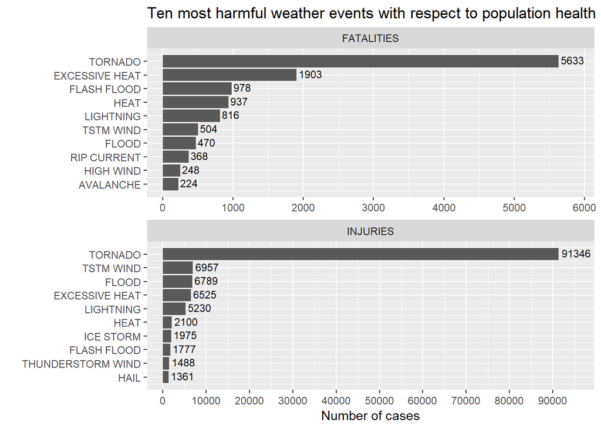

```r
require(scales, quietly = TRUE)
g <- ggplot(data = health,
            aes(x = R,  # we use row numbers now to keep the data in order
                y = COUNT)) +
    geom_col() +
    labs(x = "",
         y = "Number of cases",
         title = "Ten most harmful weather events with respect to population health") +
    facet_wrap(TYPE~.,
               scales = "free",
               nrow = 2) +
    scale_x_reverse(breaks = health$R,
                    # replacing row numbers with event type names
                    labels = health$EVTYPE) +
    # Adding more tick labels
    scale_y_continuous(breaks = pretty_breaks(n = 8),
                       expand = c(.04, 0, .09, 0)) +
    # Adding numerical values to the plot
    geom_text(aes(label = COUNT),
              size = 3,
              vjust=.35,
              hjust=-0.1,
              color = "black") +
    coord_flip()
print(g)
```

As can be seen, tornadoes caused the most fatalities and injuries, followed by excessive heat and flood events. Also, hail and ice storm caused a lot of injuries, but didn’t appear in the most fatal events list.  
Let’s estimate the contribution of the shown events in total number of injuries and fatalities:

```r
total_dead <- sum(by_event$FATALITIES)
total_inj <- sum(by_event$INJURIES)
top_ten_dead <- sum(health$COUNT[health$TYPE == "FATALITIES"])
top_ten_inj <- sum(health$COUNT[health$TYPE == "INJURIES"])
fraction_dead <- round(top_ten_dead / total_dead * 100)
fraction_injured <- round(top_ten_inj / total_inj * 100)
```

The shown events account for 80 % of fatalities and 89 % of injuries.

### Economic consequences

Let’s create a separate variable following the procedure we employed in the previous case. We keep property and crop damages separated.

```r
dmg <- by_event %>%
    # Select relevant variables
    select(c(1, 4, 5)) %>%
    gather(key = "TYPE", value = "AMOUNT", -EVTYPE) %>%
    arrange(desc(AMOUNT)) %>%
    group_by(TYPE) %>%
    # Keep ten most harmful events
    slice(1:10) %>%
    ungroup() %>%
    mutate(R = row_number())
```

Let’s now plot the data.

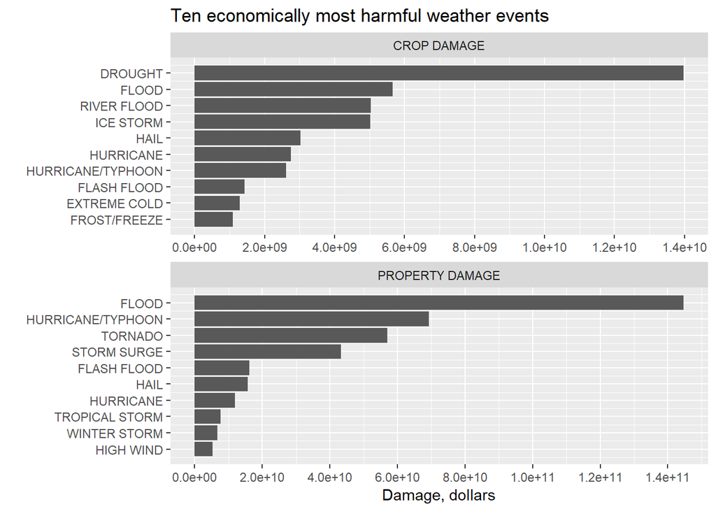

```r
require(scales, quietly = TRUE)
# Future facet labels
labels <- c(CROPDMG="CROP DAMAGE", PROPDMG="PROPERTY DAMAGE")
g <- ggplot(data = dmg,
            aes(x = R,
                y = AMOUNT)) +
    geom_col() +
    labs(x = "",
         y = "Damage, dollars",
         title = "Ten economically most harmful weather events") +
    facet_wrap(TYPE~.,
               scales = "free",
               nrow = 2,
               labeller = labeller(TYPE = labels)) +
    scale_x_reverse(breaks = dmg$R,
                    labels = dmg$EVTYPE) +
    scale_y_continuous(breaks = pretty_breaks(n = 8),
                       labels = scientific) +
    coord_flip()
print(g)
```

As can be seen, the most destructive events, such as tornadoes and floods, cause the most property damage, while the weather events that affect crop yeild or can inflict physical damage on plants (i.e. drought, flood or hail) account for the largest part of the crop damage.  
As in the case with health counsequences, let’s have a look at the contribution of the shown events in total economic damage:

```r
total_propdmg <- sum(by_event$PROPDMG)
total_cropdmg <- sum(by_event$CROPDMG)
top_ten_propdmg <- sum(dmg$AMOUNT[dmg$TYPE == "PROPDMG"])
top_ten_cropdmg <- sum(dmg$AMOUNT[dmg$TYPE == "CROPDMG"])
fraction_prop <- round(top_ten_propdmg / total_propdmg * 100)
fraction_crop <- round(top_ten_cropdmg / total_cropdmg * 100)
```

The shown events account for 88 % of property damage and 85 % of crop damage.